# Red Wine Quality Exploration

This report explored a dataset containing quality and attributes for approximately 1600 wines, and intented to answer: Which chemical properties influence the quality of red wines?

### Data Summary

Let’s look at a snapshot of the data and some summary statistics.  
This tidy data set contains 1,599 red wines with 11 variables on the chemical properties of the wine. At least 3 wine experts rated the quality of each wine, providing a rating between 0 (very bad) and 10 (very excellent). The dataset contains wine quality from 3 to 8.

```
## 'data.frame':    1599 obs. of  13 variables:
##  $ X                   : int  1 2 3 4 5 6 7 8 9 10 ...
##  $ fixed.acidity       : num  7.4 7.8 7.8 11.2 7.4 7.4 7.9 7.3 7.8 7.5 ...
##  $ volatile.acidity    : num  0.7 0.88 0.76 0.28 0.7 0.66 0.6 0.65 0.58 0.5 ...
##  $ citric.acid         : num  0 0 0.04 0.56 0 0 0.06 0 0.02 0.36 ...
##  $ residual.sugar      : num  1.9 2.6 2.3 1.9 1.9 1.8 1.6 1.2 2 6.1 ...
##  $ chlorides           : num  0.076 0.098 0.092 0.075 0.076 0.075 0.069 0.065 0.073 0.071 ...
##  $ free.sulfur.dioxide : num  11 25 15 17 11 13 15 15 9 17 ...
##  $ total.sulfur.dioxide: num  34 67 54 60 34 40 59 21 18 102 ...
##  $ density             : num  0.998 0.997 0.997 0.998 0.998 ...
##  $ pH                  : num  3.51 3.2 3.26 3.16 3.51 3.51 3.3 3.39 3.36 3.35 ...
##  $ sulphates           : num  0.56 0.68 0.65 0.58 0.56 0.56 0.46 0.47 0.57 0.8 ...
##  $ alcohol             : num  9.4 9.8 9.8 9.8 9.4 9.4 9.4 10 9.5 10.5 ...
##  $ quality             : int  5 5 5 6 5 5 5 7 7 5 ...
```

```
##        X          fixed.acidity   volatile.acidity  citric.acid
##  Min.   :   1.0   Min.   : 4.60   Min.   :0.1200   Min.   :0.000
##  1st Qu.: 400.5   1st Qu.: 7.10   1st Qu.:0.3900   1st Qu.:0.090
##  Median : 800.0   Median : 7.90   Median :0.5200   Median :0.260
##  Mean   : 800.0   Mean   : 8.32   Mean   :0.5278   Mean   :0.271
##  3rd Qu.:1199.5   3rd Qu.: 9.20   3rd Qu.:0.6400   3rd Qu.:0.420
##  Max.   :1599.0   Max.   :15.90   Max.   :1.5800   Max.   :1.000
##  residual.sugar     chlorides       free.sulfur.dioxide
##  Min.   : 0.900   Min.   :0.01200   Min.   : 1.00
##  1st Qu.: 1.900   1st Qu.:0.07000   1st Qu.: 7.00
##  Median : 2.200   Median :0.07900   Median :14.00
##  Mean   : 2.539   Mean   :0.08747   Mean   :15.87
##  3rd Qu.: 2.600   3rd Qu.:0.09000   3rd Qu.:21.00
##  Max.   :15.500   Max.   :0.61100   Max.   :72.00
##  total.sulfur.dioxide    density             pH          sulphates
##  Min.   :  6.00       Min.   :0.9901   Min.   :2.740   Min.   :0.3300
##  1st Qu.: 22.00       1st Qu.:0.9956   1st Qu.:3.210   1st Qu.:0.5500
##  Median : 38.00       Median :0.9968   Median :3.310   Median :0.6200
##  Mean   : 46.47       Mean   :0.9967   Mean   :3.311   Mean   :0.6581
##  3rd Qu.: 62.00       3rd Qu.:0.9978   3rd Qu.:3.400   3rd Qu.:0.7300
##  Max.   :289.00       Max.   :1.0037   Max.   :4.010   Max.   :2.0000
##     alcohol         quality
##  Min.   : 8.40   Min.   :3.000
##  1st Qu.: 9.50   1st Qu.:5.000
##  Median :10.20   Median :6.000
##  Mean   :10.42   Mean   :5.636
##  3rd Qu.:11.10   3rd Qu.:6.000
##  Max.   :14.90   Max.   :8.000
```

Since we are most interested in the quality of wine, it will be helpful to look at the target variable.

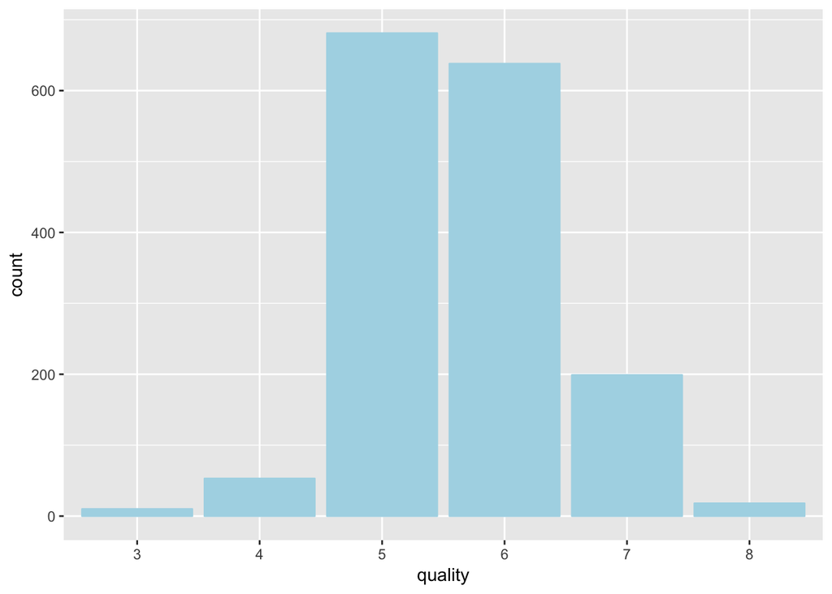

```r
wine$quality = factor(wine$quality)
ggplot(aes(x=quality), data = wine)+
  geom_histogram(stat="count", color = I('lightblue'),fill = I('lightblue'))
```

### Univariate Plots Section

11 attributes are analyzed in this report, including: - fixed.acidity  
- volatile.acidity  
- citric.acid  
- residual.sugar  
- chlorides  
- free.sulfur.dioxide  
- total.sulfur.dioxide  
- density  
- pH  
- sulphates  
- alcohol

Some other features that would also be interesting to explore but are not in this dataset. - year of the wine - origin of the wine - type of the wine, Cabernet Franc, Cabernet Sauvignon, Gamay, Grenache/Garnacha and Malbec etc.

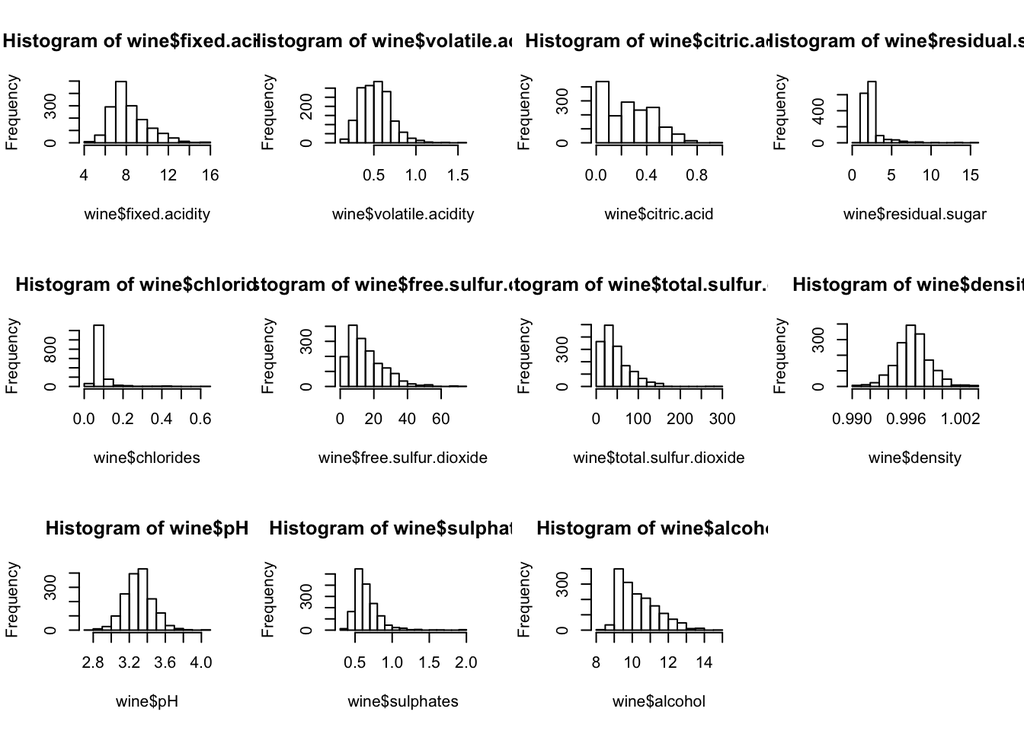

### Univariate Analysis

- It appears that density and pH are normally distributed, with few outliers.
- Fixed and volatile acidity, sulfur dioxides, sulphates, and alcohol seem to be long-tailed.
- Qualitatively, residual sugar and chlorides have extreme outliers.
- Citric acid appeared to have a large number of zero values. I’m curious whether this is truly zero, or if it is a case of non-reporting.

### Bivariate Plots Section

```r
quality_groups = group_by(wine, quality)
wine.by_quality = summarise(quality_groups,
          fixed.acidity_mean = mean(fixed.acidity),
          volatile.acidity_mean = mean(volatile.acidity),
          citric.acid_mean = mean(citric.acid),
          residual.sugar_mean = mean(residual.sugar),
          chlorides_mean = mean(chlorides),
          free.sulfur.dioxide_mean = mean(free.sulfur.dioxide),
          total.sulfur.dioxide_mean = mean(total.sulfur.dioxide),
          density_mean = mean(density),
          pH_mean = mean(pH),
          sulphates_mean = mean(sulphates),
          alcohol_mean = mean(alcohol),
          n = n())
head(wine.by_quality,10)
```

```
## # A tibble: 6 x 13
##   quality fixed.acidity_mean volatile.acidity_mean citric.acid_mean
##    <fctr>              <dbl>                 <dbl>            <dbl>
## 1       3           8.360000             0.8845000        0.1710000
## 2       4           7.779245             0.6939623        0.1741509
## 3       5           8.167254             0.5770411        0.2436858
## 4       6           8.347179             0.4974843        0.2738245
## 5       7           8.872362             0.4039196        0.3751759
## 6       8           8.566667             0.4233333        0.3911111
## # ... with 9 more variables: residual.sugar_mean <dbl>,
## #   chlorides_mean <dbl>, free.sulfur.dioxide_mean <dbl>,
## #   total.sulfur.dioxide_mean <dbl>, density_mean <dbl>, pH_mean <dbl>,
## #   sulphates_mean <dbl>, alcohol_mean <dbl>, n <int>
```

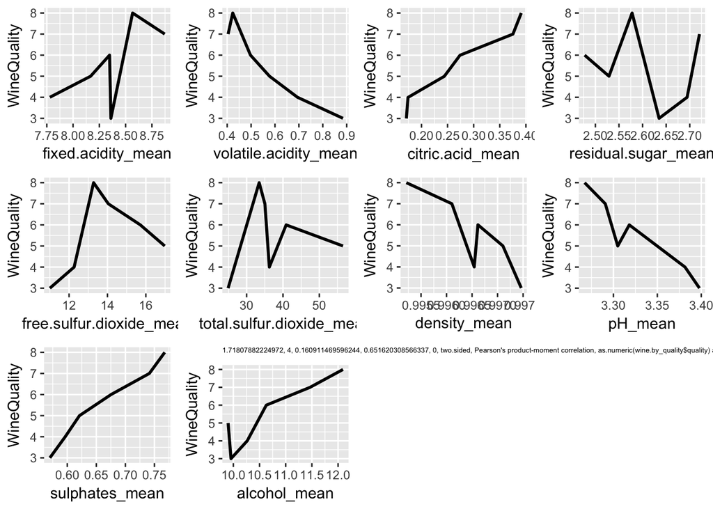

```r
WineQuality =  c(3,4,5,6,7,8)

c1 = cor.test(as.numeric(wine.by_quality$quality),wine.by_quality$fixed.acidity_mean)

p1 <- ggplot(aes(y=WineQuality, x=fixed.acidity_mean), data = wine.by_quality) +
  geom_line(size = 1)

p2 <- ggplot(aes(y= WineQuality, x=volatile.acidity_mean), data = wine.by_quality) +
  geom_line(size = 1)

p3 <- ggplot(aes(y= WineQuality, x=citric.acid_mean), data = wine.by_quality) +
  geom_line(size = 1)

p4 <- ggplot(aes(y= WineQuality, x=residual.sugar_mean), data = wine.by_quality) +
  geom_line(size = 1)

p5 <- ggplot(aes(y= WineQuality, x=free.sulfur.dioxide_mean), data = wine.by_quality) +
  geom_line(size = 1)

p6 <- ggplot(aes(y= WineQuality, x=total.sulfur.dioxide_mean), data = wine.by_quality) +
  geom_line(size = 1)

p7 <- ggplot(aes(y= WineQuality, x=density_mean), data = wine.by_quality) +
  geom_line(size = 1)

p8 <- ggplot(aes(y= WineQuality, x=pH_mean), data = wine.by_quality) +
  geom_line(size = 1)

p9 <- ggplot(aes(y= WineQuality, x=sulphates_mean), data = wine.by_quality) +
  geom_line(size = 1)

p10 <- ggplot(aes(y= WineQuality, x=alcohol_mean), data = wine.by_quality) +
  geom_line(size = 1)+
   ggtitle(toString(c1) )+
   theme(plot.title=element_text(size=5))

grid.arrange(p1, p2, p3, p4, p5, p6, p7, p8, p9, p10, ncol = 4)
```

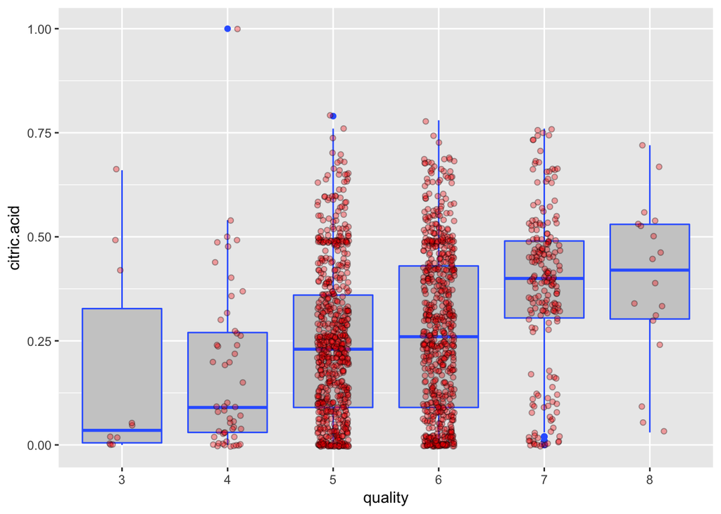

```r
ggplot(aes(x=quality , y=citric.acid), data = wine)+
  geom_boxplot(fill = "grey80", colour = "#3366FF")+
  geom_jitter(fill = I('red'),shape = 21,alpha = 1/3, width = 0.15)
```

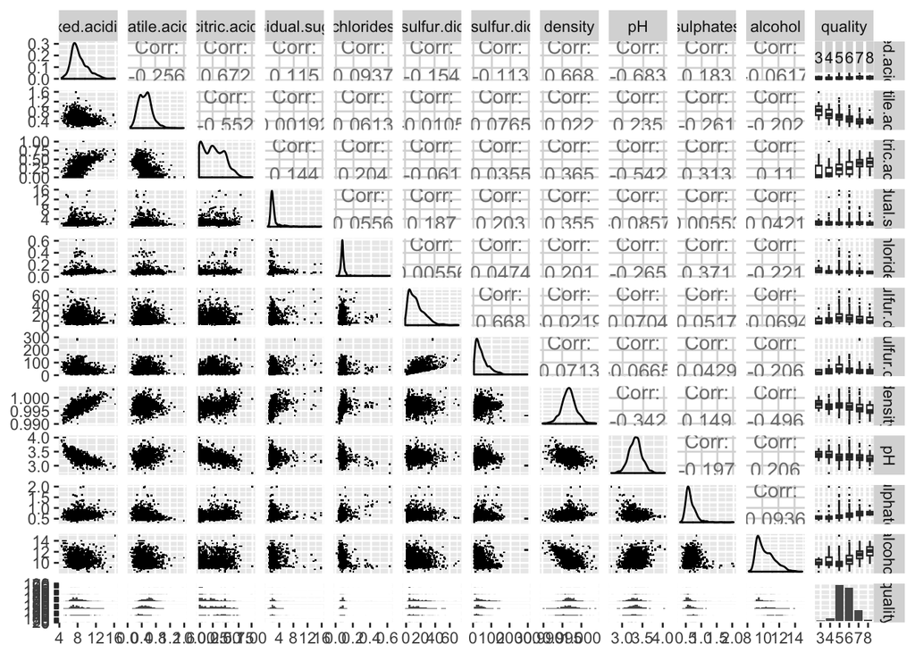

```r
ggpairs(subset(wine, select = -c(X)),
  lower = list(continuous = wrap("points", shape = I('.'))),
  upper = list(combo = wrap("box", outlier.shape = I('.'))))
```

### Bivariate Analysis

Based on the ggpairs above, we observed the following relationship between the wine quality and other variables: - negative correlation bewteen volatile.acidity and wine quality - positive correlation bewteen citric.acid and wine quality - positive correlation bewteen sulphates and wine quality

Some interesting discovery of the relationship between the variables include: - fixed.acidity is positive correlated to density. This makes sense since most of the wine volume is made of water, fixed.acidity is known as more dense than water - fixed.acidity is negative correlated to PH. This makes sense since the more acid in a certain solution, the lower PH based on chemical knowedge.

Strongest relationship among all variables is between fixed.acidity and PH, with Corr = -0.683 Strongest relationship for wine quality is between alcohol and wine quality, with Corr = 0.476

### Multivariate Plots Section

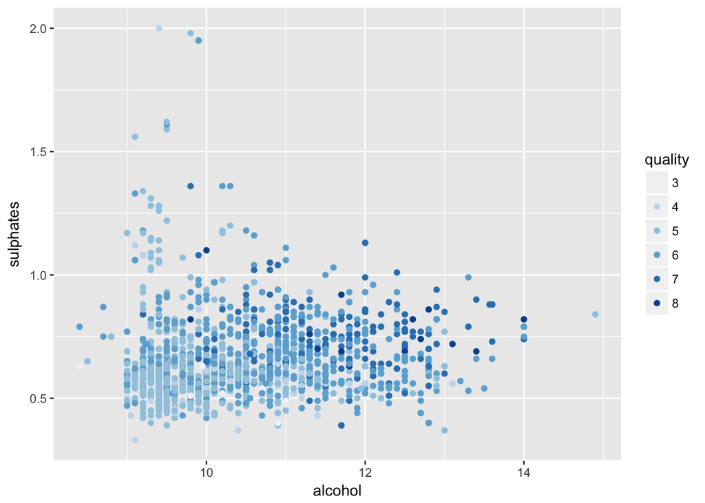

```r
ggplot(data = wine,
       aes(y = sulphates, x = alcohol,
           color = quality)) +
  geom_point() +
  scale_color_brewer()
```

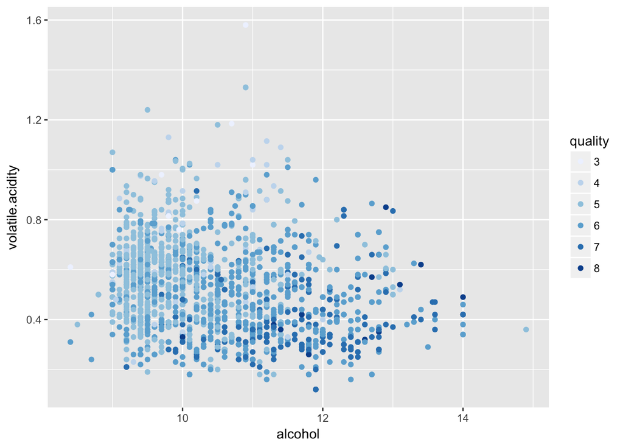

```r
ggplot(data = wine,
       aes(y = volatile.acidity, x = alcohol,
           color = quality)) +
  geom_point() +
  scale_color_brewer()
```

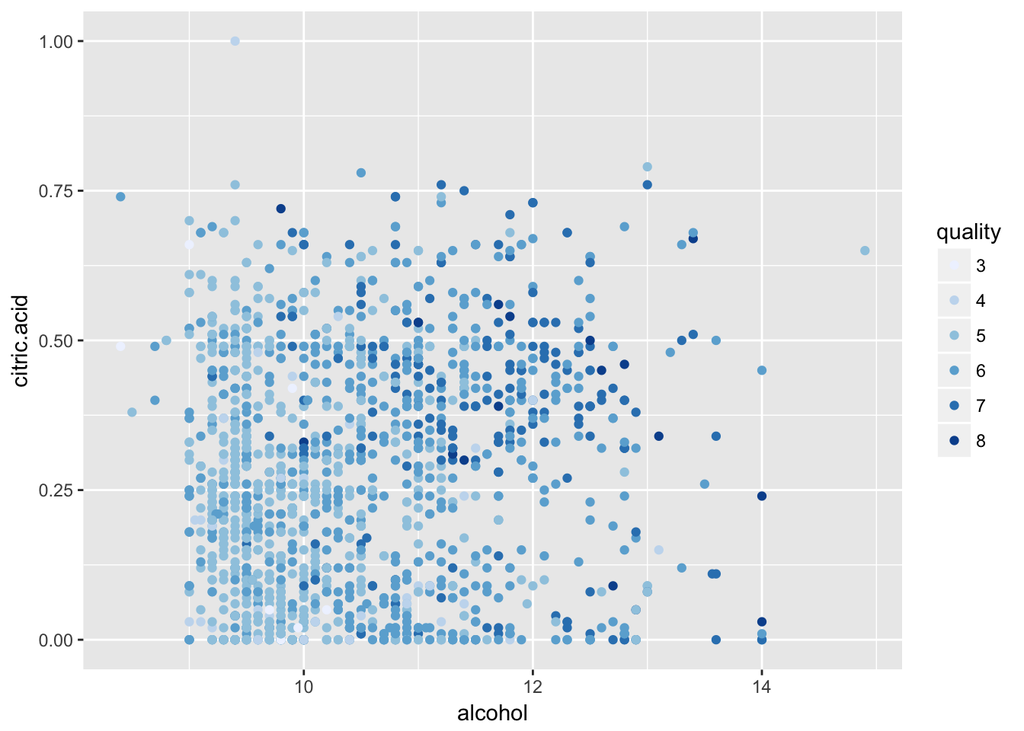

```r
ggplot(data = wine,
       aes(y = citric.acid, x = alcohol,
           color = quality)) +
  geom_point() +
  scale_color_brewer()
```

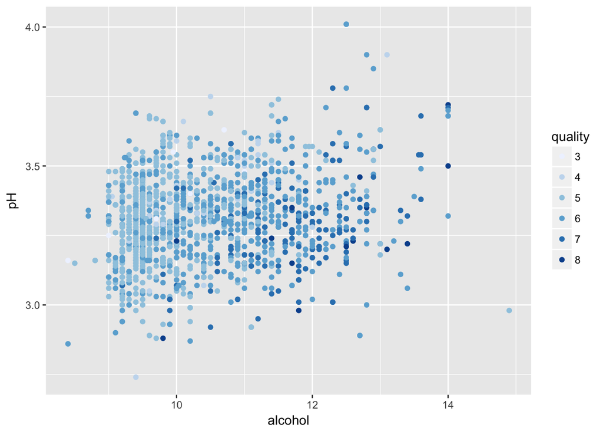

```r
ggplot(data = wine,
       aes(y = pH, x = alcohol,
           color = quality)) +
  geom_point() +
  scale_color_brewer()
```

### Multivariate Analysis

I also created a explanatory model to model the wine quality, using the 5 factors due to their high corr with wine quality: alcohol, sulphates, volatile.acidity, citric.acid and pH.

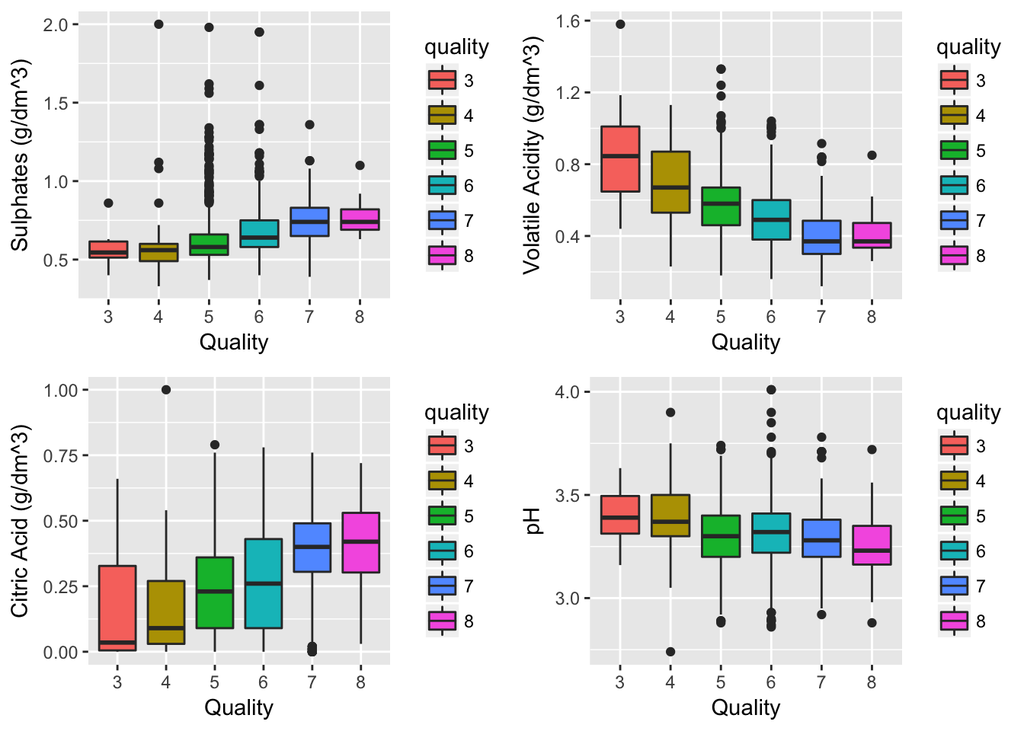

```r
grid.arrange(ggplot(data = wine, aes(x = quality, y = sulphates,
                                   fill = quality)) +
               ylab('Sulphates (g/dm^3)') +
               xlab('Quality') +
               geom_boxplot(),
             ggplot(data = wine, aes(x = quality, y = volatile.acidity,
                                   fill = quality)) +
               ylab('Volatile Acidity (g/dm^3)') +
               xlab('Quality') +
               geom_boxplot(),
             ggplot(data = wine, aes(x = quality, y = citric.acid,
                                   fill = quality)) +
               ylab('Citric Acid (g/dm^3)') +
               xlab('Quality') +
               geom_boxplot(),
             ggplot(data = wine, aes(x = quality, y = pH,
                                   fill = quality)) +
               ylab('pH') +
               xlab('Quality') +
               geom_boxplot())
```

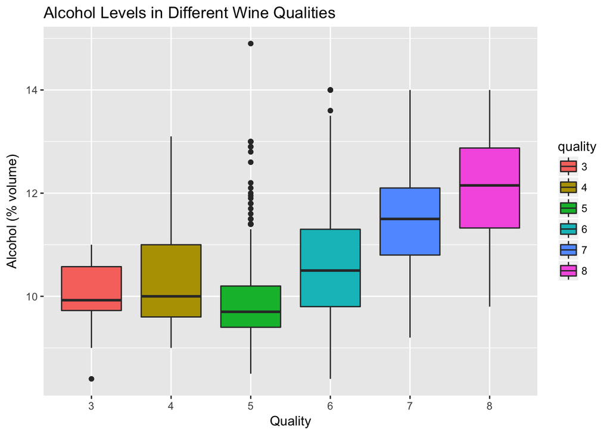

```r
ggplot(data = wine, aes(x = quality, y = alcohol,
                      fill = quality)) +
  geom_boxplot() +
  ggtitle('Alcohol Levels in Different Wine Qualities') +
  xlab('Quality') +
  ylab('Alcohol (% volume)')
```

```r
m1 <- lm(I(as.numeric(quality)) ~ I(alcohol), data = wine)
m2 <- update(m1, ~ . + sulphates)
m3 <- update(m2, ~ . +volatile.acidity)
m4 <- update(m3, ~ . + citric.acid)
m5 <- update(m4, ~ . + pH)
mtable(m1, m2, m3, m4, m5)
```

```
##
## Calls:
## m1: lm(formula = I(as.numeric(quality)) ~ I(alcohol), data = wine)
## m2: lm(formula = I(as.numeric(quality)) ~ I(alcohol) + sulphates,
##     data = wine)
## m3: lm(formula = I(as.numeric(quality)) ~ I(alcohol) + sulphates +
##     volatile.acidity, data = wine)
## m4: lm(formula = I(as.numeric(quality)) ~ I(alcohol) + sulphates +
##     volatile.acidity + citric.acid, data = wine)
## m5: lm(formula = I(as.numeric(quality)) ~ I(alcohol) + sulphates +
##     volatile.acidity + citric.acid + pH, data = wine)
##
## ==========================================================================================
##                          m1            m2            m3            m4            m5
## ------------------------------------------------------------------------------------------
##   (Intercept)          -0.125        -0.625***      0.611**       0.646**       2.112***
##                        (0.175)       (0.177)       (0.196)       (0.201)       (0.459)
##   I(alcohol)            0.361***      0.346***      0.309***      0.309***      0.327***
##                        (0.017)       (0.016)       (0.016)       (0.016)       (0.017)
##   sulphates                           0.994***      0.679***      0.696***      0.673***
##                                      (0.102)       (0.101)       (0.103)       (0.103)
##   volatile.acidity                                 -1.221***     -1.265***     -1.284***
##                                                    (0.097)       (0.113)       (0.112)
##   citric.acid                                                    -0.079        -0.297*
##                                                                  (0.104)       (0.120)
##   pH                                                                           -0.475***
##                                                                                (0.134)
## ------------------------------------------------------------------------------------------
##   R-squared             0.227         0.270         0.336         0.336         0.341
##   adj. R-squared        0.226         0.269         0.335         0.334         0.339
##   sigma                 0.710         0.690         0.659         0.659         0.656
##   F                   468.267       294.988       268.912       201.777       165.112
##   p                     0.000         0.000         0.000         0.000         0.000
##   Log-likelihood    -1721.057     -1675.142     -1599.384     -1599.093     -1592.801
##   Deviance            805.870       760.894       692.105       691.852       686.429
##   AIC                3448.114      3358.284      3208.768      3210.186      3199.602
##   BIC                3464.245      3379.793      3235.654      3242.448      3237.242
##   N                  1599          1599          1599          1599          1599
## ==========================================================================================
```